# 04 — Classification de l'âge au premier alcool

On prédit une version discrétisée de l'âge au premier alcool, en **regroupant 14 et 15 ans** :

| Classe | Contenu |
| --- | --- |
| ≤ 13 ans | initiation précoce |
| 14-15 ans | âge le plus courant |
| ≥ 16 ans | initiation tardive |
| Non concerné | n'a jamais bu (`Q19A` manquant) |

Pourquoi ce regroupement : avec le découpage en quartiles (≤ 13 / 14 / 15 / ≥ 16), les modèles ne distinguaient pas les jeunes de 14 et 15 ans (mêmes probabilités prédites, classe « 14 ans » jamais prédite). Les seuils (13 et 15) sont donc fixés à la main et non plus par quantiles. Contrepartie : la classe 14-15 ans regroupe environ 41 % des jeunes ; les scores (exactitude notamment) ne sont pas comparables tels quels avec la version à 5 classes, on les lit par rapport à la référence « classe majoritaire ».

Par rapport à la régression (`03_modeles.py`) :

- **tous les jeunes sont modélisés**, y compris ceux qui n'ont jamais bu ;
- les âges extrêmes (1 à 5 ans) ne pèsent plus plus que les autres ;
- le problème devient : reconnaître les profils précoces, tardifs ou abstinents.

## Variables explicatives

Les mêmes que pour la régression (`data/features.py`), pour les mêmes raisons : sexe, redoublement, difficultés de lecture / écriture, consommation d'alcool des parents (scores ordinaux + indicatrice de non-réponse), `SITUATION`, lieu de vie, vie des parents, situation et PCS des parents (indicatrices). Exclues : `A01` (identifiant), `pm17B` (pondération), `Q04`/`Q04A`/`Q04B` (résumées par `SITUATION`), `Q19A` (la cible continue : fuite d'information).

## Protocole

- Découpage 80 % apprentissage / 20 % test, stratifié sur la classe.
- Hyperparamètres choisis par validation croisée à 5 plis en minimisant la **log-loss pondérée** : elle évalue les probabilités prédites, ce qui est plus stable que l'exactitude quand le signal est faible (les modèles tendent à prédire toujours les mêmes classes).
- Apprentissage et métriques pondérés par `pm17B` : log-loss, exactitude, F1 macro (moyenne des F1 de chaque classe, sensible aux classes peu prédites) et AUC macro One-vs-Rest (moyenne des AUC « classe k contre les autres » : capacité des probabilités à classer les individus, sans dépendre de la classe prédite).

```python
import sys
import time
from pathlib import Path

import matplotlib.pyplot as plt
import numpy as np
import pandas as pd
from joblib import Parallel, delayed
from sklearn.base import clone
from sklearn.dummy import DummyClassifier
from sklearn.ensemble import (
    BaggingClassifier,
    GradientBoostingClassifier,
    HistGradientBoostingClassifier,
    RandomForestClassifier,
    StackingClassifier,
)
from sklearn.inspection import permutation_importance
from sklearn.linear_model import LogisticRegression
from sklearn.metrics import accuracy_score, confusion_matrix, f1_score, log_loss, roc_auc_score
from sklearn.model_selection import ParameterGrid, StratifiedKFold, train_test_split
from sklearn.pipeline import Pipeline
from sklearn.preprocessing import LabelEncoder
from sklearn.tree import DecisionTreeClassifier
from xgboost import XGBClassifier

ROOT = Path.cwd() if (Path.cwd() / "data").is_dir() else Path.cwd().parent
sys.path.insert(0, str(ROOT))

from data import load_escap_data, preprocess  # noqa: E402
from data.features import FEATURES, make_preprocessor  # noqa: E402
from data.labels import VARIABLES, WEIGHT  # noqa: E402
from data.preprocess import TARGET_CLASS  # noqa: E402

pd.set_option("display.width", 200)
pd.set_option("display.max_columns", 50)

SEED = 42
N_JOBS = -1

BLUE = "#2a78d6"
ORANGE = "#eb6834"
GREY = "#8a8985"
TEXT = "#52514e"
BLUE_RAMP = ["#ffffff", "#cde2fb", "#86b6ef", "#3987e5", "#1c5cab", "#0d366b"]

plt.rcParams.update(
    {
        "figure.dpi": 110,
        "axes.spines.top": False,
        "axes.spines.right": False,
        "axes.edgecolor": GREY,
        "axes.labelcolor": TEXT,
        "axes.titleweight": "bold",
        "axes.titlesize": 11,
        "axes.labelsize": 9,
        "xtick.color": TEXT,
        "ytick.color": TEXT,
        "xtick.labelsize": 8,
        "ytick.labelsize": 8,
        "axes.grid": True,
        "grid.color": "#e4e3df",
        "grid.linewidth": 0.6,
        "axes.axisbelow": True,
        "legend.frameon": False,
        "legend.fontsize": 8,
    }
)
```

## Données

```python
THRESHOLDS = [13, 15]  # classes : ≤ 13, 14-15, ≥ 16 ans
df = preprocess(load_escap_data(), thresholds=THRESHOLDS)
CLASSES = list(df[TARGET_CLASS].cat.categories)

X, y, w = df[FEATURES], df[TARGET_CLASS].astype(str), df[WEIGHT]
X_train, X_test, y_train, y_test, w_train, w_test = train_test_split(
    X, y, w, test_size=0.2, stratify=y, random_state=SEED
)

print(f"Individus : {len(df)} — apprentissage : {len(X_train)}, test : {len(X_test)}")
shares = w.groupby(y).sum().reindex(CLASSES) / w.sum() * 100
pd.DataFrame({"effectif": y.value_counts().reindex(CLASSES), "% pondéré": shares.round(1)})
```

```
Individus : 13311 — apprentissage : 10648, test : 2663
```

| Q19A_CLASSE | effectif | % pondéré |
| --- | --- | --- |
| ≤ 13 ans | 2551 | 19.1 |
| 14-15 ans | 5394 | 40.5 |
| ≥ 16 ans | 2973 | 22.1 |
| Non concerné | 2393 | 18.3 |

## Outils : validation croisée pondérée et métriques

```python
def make_pipe(estimator) -> Pipeline:
    return Pipeline([("prep", make_preprocessor()), ("model", estimator)])


def weighted_log_loss(pipe, X_, y_, w_):
    return log_loss(y_, pipe.predict_proba(X_), sample_weight=w_, labels=pipe.classes_)


CV = list(StratifiedKFold(5, shuffle=True, random_state=SEED).split(X_train, y_train))


def _fit_score(estimator, params, train_idx, val_idx):
    pipe = make_pipe(clone(estimator).set_params(**params))
    pipe.fit(
        X_train.iloc[train_idx], y_train.iloc[train_idx],
        model__sample_weight=w_train.iloc[train_idx].to_numpy(),
    )
    return weighted_log_loss(
        pipe, X_train.iloc[val_idx], y_train.iloc[val_idx], w_train.iloc[val_idx]
    )


def grid_search(estimator, grid) -> pd.DataFrame:
    """Log-loss pondérée en validation croisée pour chaque combinaison d'hyperparamètres."""
    combos = list(ParameterGrid(grid))
    scores = Parallel(n_jobs=N_JOBS)(
        delayed(_fit_score)(estimator, p, tr, va) for p in combos for tr, va in CV
    )
    scores = np.asarray(scores).reshape(len(combos), len(CV))
    res = pd.DataFrame(combos)
    res["logloss_cv"], res["logloss_cv_std"] = scores.mean(1), scores.std(1)
    res["params"] = combos
    return res.sort_values("logloss_cv").reset_index(drop=True)


RESULTS = {}
FITTED = {}


def evaluate(name, estimator, grid=None):
    """Choisit les hyperparamètres en CV, réapprend sur tout l'apprentissage, évalue sur le test."""
    start = time.time()
    search = grid_search(estimator, grid or {})
    best = search.iloc[0]
    pipe = make_pipe(clone(estimator).set_params(**best["params"]))
    pipe.fit(X_train, y_train, model__sample_weight=w_train.to_numpy())
    pred = pipe.predict(X_test)
    proba = pipe.predict_proba(X_test)
    FITTED[name] = pipe
    RESULTS[name] = {
        "log-loss CV": best["logloss_cv"],
        "± CV": best["logloss_cv_std"],
        "log-loss test": weighted_log_loss(pipe, X_test, y_test, w_test),
        "exactitude test": accuracy_score(y_test, pred, sample_weight=w_test),
        "F1 macro test": f1_score(y_test, pred, average="macro", sample_weight=w_test),
        "AUC macro test": roc_auc_score(y_test, proba, multi_class="ovr", average="macro",
                                        sample_weight=w_test, labels=pipe.classes_),
        "temps (s)": time.time() - start,
        "hyperparamètres": best["params"],
    }
    print(f"{name} — meilleurs hyperparamètres : {best['params']}")
    print(pd.Series(RESULTS[name]).drop("hyperparamètres").round(4).to_string())
    return search.drop(columns="params")
```

## Modèles de référence

- **Classe majoritaire** (probabilités = fréquences des classes) : ce qu'il faut battre.
- **Régressions logistiques multinomiales pénalisées**, `C` étant l'inverse de la force de pénalité :
  - **ridge** (L2) : réduit tous les coefficients sans en annuler ;
  - **lasso** (L1) : annule une partie des coefficients (sélection de variables) ;
  - **elastic net** : mélange des deux, `l1_ratio` étant la part de L1.

  Les variables ne sont pas standardisées (scores ordinaux de 1 à k et indicatrices 0/1, d'échelles proches).
- **Arbre de décision** seul.

```python
evaluate("Classe majoritaire", DummyClassifier(strategy="prior"))
```

```
Classe majoritaire — meilleurs hyperparamètres : {}
log-loss CV        1.3267
± CV               0.0016
log-loss test      1.3255
exactitude test    0.4072
F1 macro test      0.1447
AUC macro test        0.5
temps (s)          2.3943
```

|  | logloss_cv | logloss_cv_std |
| --- | --- | --- |
| 0 | 1.32668 | 0.001612 |

```python
evaluate(
    "Logistique ridge",
    LogisticRegression(max_iter=5000),
    {"C": [float(c) for c in np.logspace(-3, 1, 9)]},
)
```

```
Logistique ridge — meilleurs hyperparamètres : {'C': 0.03162277660168379}
log-loss CV        1.2496
± CV               0.0044
log-loss test      1.2478
exactitude test    0.4432
F1 macro test      0.2788
AUC macro test      0.645
temps (s)          4.5016
```

|  | C | logloss_cv | logloss_cv_std |
| --- | --- | --- | --- |
| 0 | 0.031623 | 1.249577 | 0.004444 |
| 1 | 0.010000 | 1.250062 | 0.003951 |
| 2 | 0.100000 | 1.251119 | 0.004817 |
| 3 | 0.316228 | 1.253049 | 0.005166 |
| 4 | 1.000000 | 1.254446 | 0.005375 |
| 5 | 0.003162 | 1.254834 | 0.003567 |
| 6 | 3.162278 | 1.255078 | 0.005592 |
| 7 | 10.000000 | 1.255492 | 0.005779 |
| 8 | 0.001000 | 1.264978 | 0.003233 |

```python
evaluate(
    "Logistique lasso",
    LogisticRegression(l1_ratio=1.0, solver="saga", max_iter=5000),
    {"C": [float(c) for c in np.logspace(-3, 1, 9)]},
)
```

```
Logistique lasso — meilleurs hyperparamètres : {'C': 0.1}
log-loss CV         1.2504
± CV                0.0039
log-loss test        1.247
exactitude test     0.4446
F1 macro test       0.2715
AUC macro test      0.6462
temps (s)          19.6527
```

|  | C | logloss_cv | logloss_cv_std |
| --- | --- | --- | --- |
| 0 | 0.100000 | 1.250354 | 0.003937 |
| 1 | 0.316228 | 1.250574 | 0.004718 |
| 2 | 1.000000 | 1.252812 | 0.005218 |
| 3 | 3.162278 | 1.254689 | 0.005649 |
| 4 | 10.000000 | 1.255615 | 0.005931 |
| 5 | 0.031623 | 1.257887 | 0.003149 |
| 6 | 0.010000 | 1.275247 | 0.004837 |
| 7 | 0.003162 | 1.289081 | 0.003322 |
| 8 | 0.001000 | 1.321390 | 0.001339 |

```python
evaluate(
    "Logistique elastic net",
    LogisticRegression(solver="saga", max_iter=5000),
    {"C": [float(c) for c in np.logspace(-3, 1, 9)], "l1_ratio": [0.25, 0.5, 0.75]},
).head()
```

```
Logistique elastic net — meilleurs hyperparamètres : {'C': 0.1, 'l1_ratio': 0.5}
log-loss CV        1.2498
± CV               0.0043
log-loss test      1.2475
exactitude test    0.4443
F1 macro test      0.2763
AUC macro test     0.6455
temps (s)          33.842
```

|  | C | l1_ratio | logloss_cv | logloss_cv_std |
| --- | --- | --- | --- | --- |
| 0 | 0.100000 | 0.50 | 1.249832 | 0.004276 |
| 1 | 0.100000 | 0.25 | 1.249988 | 0.004475 |
| 2 | 0.100000 | 0.75 | 1.250077 | 0.004147 |
| 3 | 0.031623 | 0.25 | 1.250353 | 0.003713 |
| 4 | 0.316228 | 0.75 | 1.250845 | 0.004724 |

Nombre de coefficients non nuls (pour au moins une classe) et variables entièrement écartées par le lasso et l'elastic net.

```python
LOGITS = ("Logistique ridge", "Logistique lasso", "Logistique elastic net")
coef_names = FITTED["Logistique ridge"].named_steps["prep"].get_feature_names_out()
nonzero = pd.DataFrame(
    {n: np.abs(FITTED[n].named_steps["model"].coef_).max(0) > 1e-10 for n in LOGITS},
    index=coef_names,
)
print(nonzero.sum().to_string(), f"\nsur {len(coef_names)} coefficients par classe")
nonzero[~nonzero.all(axis=1)]
```

```
Logistique ridge          67
Logistique lasso          41
Logistique elastic net    55
sur 67 coefficients par classe
```

|  | Logistique ridge | Logistique lasso | Logistique elastic net |
| --- | --- | --- | --- |
| missingindicator_Q03 | True | False | False |
| missingindicator_Q05 | True | False | False |
| missingindicator_Q06A | True | False | False |
| missingindicator_Q06B | True | False | False |
| SITUATION_Arrêt : Recherche emploi | True | False | True |
| SITUATION_Arrêt : Sans activité | True | False | False |
| SITUATION_Arrêt : Travaille | True | False | True |
| SITUATION_infrequent_sklearn | True | False | True |
| Q08_Autre | True | False | True |
| Q08_Foyer / fam. accueil | True | False | False |
| Q08_Non répondu | True | False | False |
| Q08C_Autre | True | False | False |
| Q08C_Décès | True | False | False |
| Q08C_Non répondu | True | False | False |
| Q08C_infrequent_sklearn | True | False | False |
| Q09A1_Au foyer | True | False | False |
| Q09A1_Invalidité | True | False | True |
| Q09A1_Non répondu | True | False | True |
| Q09B1_Ne sait pas | True | False | True |
| Q09B1_Non concerné | True | False | True |
| Q09B1_Retraite | True | False | True |
| Q10A1_Prof. intermédiaire | True | False | True |
| Q10B1_Agriculteur | True | False | True |
| Q10B1_Chef entr. ≥ 10 sal. | True | False | True |
| Q10B1_Non concerné | True | False | True |
| Q10B1_Ouvrier | True | False | True |

```python
evaluate(
    "Arbre",
    DecisionTreeClassifier(random_state=SEED),
    {"max_depth": [3, 4, 6, 8, 10, 12], "min_samples_leaf": [50, 100, 200, 400]},
).head()
```

```
Arbre — meilleurs hyperparamètres : {'max_depth': 6, 'min_samples_leaf': 200}
log-loss CV         1.264
± CV               0.0085
log-loss test      1.2555
exactitude test     0.439
F1 macro test      0.2937
AUC macro test     0.6274
temps (s)          1.6294
```

|  | max_depth | min_samples_leaf | logloss_cv | logloss_cv_std |
| --- | --- | --- | --- | --- |
| 0 | 6 | 200 | 1.264029 | 0.008459 |
| 1 | 8 | 200 | 1.264239 | 0.008557 |
| 2 | 12 | 200 | 1.264305 | 0.008366 |
| 3 | 10 | 200 | 1.264305 | 0.008366 |
| 4 | 4 | 100 | 1.266009 | 0.008626 |

## Bagging et forêt aléatoire

```python
evaluate(
    "Bagging",
    BaggingClassifier(DecisionTreeClassifier(), n_estimators=300, random_state=SEED, n_jobs=1),
    {"estimator__min_samples_leaf": [5, 10, 20, 50, 100], "max_samples": [0.2, 0.5, 1.0]},
).head()
```

```
Bagging — meilleurs hyperparamètres : {'estimator__min_samples_leaf': 20, 'max_samples': 0.2}
log-loss CV         1.2479
± CV                 0.007
log-loss test       1.2378
exactitude test     0.4495
F1 macro test       0.2776
AUC macro test      0.6479
temps (s)          28.0638
```

|  | estimator__min_samples_leaf | max_samples | logloss_cv | logloss_cv_std |
| --- | --- | --- | --- | --- |
| 0 | 20 | 0.2 | 1.247881 | 0.007048 |
| 1 | 10 | 0.2 | 1.248740 | 0.007001 |
| 2 | 50 | 0.5 | 1.249116 | 0.007814 |
| 3 | 50 | 1.0 | 1.250713 | 0.008589 |
| 4 | 20 | 0.5 | 1.250870 | 0.008227 |

```python
evaluate(
    "Forêt aléatoire",
    RandomForestClassifier(n_estimators=300, random_state=SEED, n_jobs=1),
    {"max_features": [0.1, 0.2, 0.33, 0.5], "min_samples_leaf": [10, 20, 50, 100]},
).head()
```

```
Forêt aléatoire — meilleurs hyperparamètres : {'max_features': 0.2, 'min_samples_leaf': 20}
log-loss CV         1.2476
± CV                0.0059
log-loss test       1.2374
exactitude test     0.4524
F1 macro test       0.2713
AUC macro test      0.6485
temps (s)          17.4078
```

|  | max_features | min_samples_leaf | logloss_cv | logloss_cv_std |
| --- | --- | --- | --- | --- |
| 0 | 0.20 | 20 | 1.247554 | 0.005916 |
| 1 | 0.33 | 50 | 1.248169 | 0.006141 |
| 2 | 0.50 | 50 | 1.248473 | 0.007277 |
| 3 | 0.20 | 50 | 1.249107 | 0.005191 |
| 4 | 0.33 | 20 | 1.249512 | 0.006581 |

## Boosting

```python
evaluate(
    "Gradient boosting",
    GradientBoostingClassifier(subsample=0.8, random_state=SEED),
    {
        "learning_rate": [0.01, 0.02, 0.05, 0.1],
        "n_estimators": [100, 300, 600],
        "max_depth": [1, 2, 3],
    },
).head()
```

```
Gradient boosting — meilleurs hyperparamètres : {'learning_rate': 0.02, 'max_depth': 2, 'n_estimators': 600}
log-loss CV          1.2436
± CV                 0.0058
log-loss test        1.2349
exactitude test      0.4525
F1 macro test         0.305
AUC macro test       0.6485
temps (s)          140.4438
```

|  | learning_rate | max_depth | n_estimators | logloss_cv | logloss_cv_std |
| --- | --- | --- | --- | --- | --- |
| 0 | 0.02 | 2 | 600 | 1.243571 | 0.005788 |
| 1 | 0.01 | 2 | 600 | 1.243875 | 0.005431 |
| 2 | 0.05 | 1 | 300 | 1.243956 | 0.004808 |
| 3 | 0.02 | 2 | 300 | 1.243962 | 0.005353 |
| 4 | 0.10 | 2 | 100 | 1.243969 | 0.005979 |

```python
evaluate(
    "Hist. gradient boosting",
    HistGradientBoostingClassifier(early_stopping=False, random_state=SEED),
    {
        "learning_rate": [0.01, 0.03, 0.1],
        "max_iter": [100, 300],
        "max_leaf_nodes": [3, 7, 15],
        "min_samples_leaf": [20, 80],
        "l2_regularization": [0.0, 1.0],
    },
).head()
```

```
Hist. gradient boosting — meilleurs hyperparamètres : {'l2_regularization': 1.0, 'learning_rate': 0.1, 'max_iter': 100, 'max_leaf_nodes': 3, 'min_samples_leaf': 80}
log-loss CV         1.2417
± CV                0.0062
log-loss test       1.2373
exactitude test     0.4547
F1 macro test       0.2896
AUC macro test      0.6459
temps (s)          76.9371
```

|  | l2_regularization | learning_rate | max_iter | max_leaf_nodes | min_samples_leaf | logloss_cv | logloss_cv_std |
| --- | --- | --- | --- | --- | --- | --- | --- |
| 0 | 1.0 | 0.10 | 100 | 3 | 80 | 1.241732 | 0.006160 |
| 1 | 1.0 | 0.03 | 300 | 3 | 80 | 1.242008 | 0.006017 |
| 2 | 0.0 | 0.03 | 300 | 3 | 80 | 1.242031 | 0.006072 |
| 3 | 1.0 | 0.10 | 100 | 3 | 20 | 1.242100 | 0.005683 |
| 4 | 0.0 | 0.10 | 100 | 3 | 80 | 1.242161 | 0.006305 |

### XGBoost

```python
class XGBLabelClassifier(XGBClassifier):
    """XGBClassifier acceptant des classes textuelles."""

    @property
    def classes_(self):
        # pendant le fit, XGBoost compare classes_ aux codes 0..K-1
        le = getattr(self, "label_encoder_", None)
        return le.classes_ if le is not None else np.arange(self.n_classes_)

    def fit(self, X, y, **kwargs):
        self.label_encoder_ = None
        le = LabelEncoder().fit(y)
        super().fit(X, le.transform(y), **kwargs)
        self.label_encoder_ = le
        return self

    def predict(self, X):
        return self.label_encoder_.inverse_transform(super().predict(X))
```

```python
evaluate(
    "XGBoost",
    XGBLabelClassifier(subsample=0.8, tree_method="hist", n_jobs=1, random_state=SEED),
    {
        "learning_rate": [0.02, 0.05, 0.1],
        "n_estimators": [100, 300, 600],
        "max_depth": [1, 2, 3],
        "colsample_bytree": [0.8, 1.0],
    },
).head()
```

```
XGBoost — meilleurs hyperparamètres : {'colsample_bytree': 0.8, 'learning_rate': 0.02, 'max_depth': 2, 'n_estimators': 600}
log-loss CV         1.2419
± CV                0.0055
log-loss test       1.2352
exactitude test      0.455
F1 macro test        0.293
AUC macro test      0.6485
temps (s)          29.5983
```

|  | colsample_bytree | learning_rate | max_depth | n_estimators | logloss_cv | logloss_cv_std |
| --- | --- | --- | --- | --- | --- | --- |
| 0 | 0.8 | 0.02 | 2 | 600 | 1.241910 | 0.005487 |
| 1 | 0.8 | 0.05 | 2 | 300 | 1.242254 | 0.005685 |
| 2 | 0.8 | 0.10 | 2 | 100 | 1.242515 | 0.005460 |
| 3 | 1.0 | 0.02 | 2 | 600 | 1.242520 | 0.005503 |
| 4 | 1.0 | 0.05 | 2 | 300 | 1.242629 | 0.005431 |

## Stacking

Régression logistique, forêt aléatoire et boosting par histogrammes (meilleurs hyperparamètres) ; leurs probabilités prédites (par validation croisée interne) alimentent une régression logistique.

```python
base = [
    ("logit", FITTED["Logistique ridge"].named_steps["model"]),
    ("rf", FITTED["Forêt aléatoire"].named_steps["model"]),
    ("hgb", FITTED["Hist. gradient boosting"].named_steps["model"]),
]
evaluate(
    "Stacking",
    StackingClassifier(
        [(n, clone(m)) for n, m in base],
        final_estimator=LogisticRegression(max_iter=5000),
        stack_method="predict_proba",
        cv=5,
        n_jobs=1,
    ),
)
```

```
Stacking — meilleurs hyperparamètres : {}
log-loss CV          1.239
± CV                0.0057
log-loss test       1.2323
exactitude test      0.453
F1 macro test       0.2861
AUC macro test      0.6516
temps (s)          34.3118
```

|  | logloss_cv | logloss_cv_std |
| --- | --- | --- |
| 0 | 1.238993 | 0.005677 |

## Comparaison des modèles

```python
results = pd.DataFrame(RESULTS).T
results_num = results.drop(columns="hyperparamètres").astype(float)
baseline = results_num.loc["Classe majoritaire", "log-loss test"]
results_num["gain log-loss vs référence (%)"] = (1 - results_num["log-loss test"] / baseline) * 100
results_num.sort_values("log-loss test").round(4)
```

|  | log-loss CV | ± CV | log-loss test | exactitude test | F1 macro test | AUC macro test | temps (s) | gain log-loss vs référence (%) |
| --- | --- | --- | --- | --- | --- | --- | --- | --- |
| Stacking | 1.2390 | 0.0057 | 1.2323 | 0.4530 | 0.2861 | 0.6516 | 34.3118 | 7.0383 |
| Gradient boosting | 1.2436 | 0.0058 | 1.2349 | 0.4525 | 0.3050 | 0.6485 | 140.4438 | 6.8360 |
| XGBoost | 1.2419 | 0.0055 | 1.2352 | 0.4550 | 0.2930 | 0.6485 | 29.5983 | 6.8141 |
| Hist. gradient boosting | 1.2417 | 0.0062 | 1.2373 | 0.4547 | 0.2896 | 0.6459 | 76.9371 | 6.6540 |
| Forêt aléatoire | 1.2476 | 0.0059 | 1.2374 | 0.4524 | 0.2713 | 0.6485 | 17.4078 | 6.6522 |
| Bagging | 1.2479 | 0.0070 | 1.2378 | 0.4495 | 0.2776 | 0.6479 | 28.0638 | 6.6175 |
| Logistique lasso | 1.2504 | 0.0039 | 1.2470 | 0.4446 | 0.2715 | 0.6462 | 19.6527 | 5.9244 |
| Logistique elastic net | 1.2498 | 0.0043 | 1.2475 | 0.4443 | 0.2763 | 0.6455 | 33.8420 | 5.8881 |
| Logistique ridge | 1.2496 | 0.0044 | 1.2478 | 0.4432 | 0.2788 | 0.6450 | 4.5016 | 5.8664 |
| Arbre | 1.2640 | 0.0085 | 1.2555 | 0.4390 | 0.2937 | 0.6274 | 1.6294 | 5.2864 |
| Classe majoritaire | 1.3267 | 0.0016 | 1.3255 | 0.4072 | 0.1447 | 0.5000 | 2.3943 | 0.0000 |

```
Meilleur modèle : Stacking — meilleur modèle d'agrégation : Stacking
```

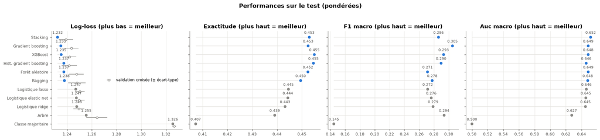

```python
REFERENCES = ("Classe majoritaire", *LOGITS, "Arbre")
order = results_num.sort_values("log-loss test", ascending=False)
best_name = order.index[-1]
best_ensemble = next(n for n in order.index[::-1] if n not in REFERENCES)
print(f"Meilleur modèle : {best_name} — meilleur modèle d'agrégation : {best_ensemble}")

colors = [GREY if n in REFERENCES else BLUE for n in order.index]
pos = np.arange(len(order))
fig, axes = plt.subplots(1, 4, figsize=(17, 4), sharey=True)
for ax, metric in zip(axes, ("log-loss test", "exactitude test", "F1 macro test",
                             "AUC macro test")):
    ax.hlines(pos, order[metric].min(), order[metric], color="#e4e3df", linewidth=1)
    ax.scatter(order[metric], pos, color=colors, s=45, zorder=3, edgecolor="white")
    for p_, v in zip(pos, order[metric]):
        ax.annotate(f"{v:.3f}", (v, p_), xytext=(0, 7), textcoords="offset points",
                    ha="center", fontsize=7, color=TEXT)
    sens = "plus bas = meilleur" if "loss" in metric else "plus haut = meilleur"
    ax.set_title(f"{metric.replace(' test', '').capitalize()} ({sens})")
    ax.set_yticks(pos, order.index)
    ax.set_ylim(-0.6, len(order) - 0.3)
    ax.grid(axis="y", visible=False)
axes[0].errorbar(order["log-loss CV"], pos - 0.25, xerr=order["± CV"], fmt="o", color=GREY,
                 markerfacecolor="white", markersize=4, elinewidth=1,
                 label="validation croisée (± écart-type)")
axes[0].legend(loc="center right")
fig.suptitle("Performances sur le test (pondérées)", fontweight="bold")
plt.tight_layout(rect=(0, 0, 1, 0.95))
plt.show()
```

## Analyse du meilleur modèle d'agrégation

### Matrice de confusion

En ligne la classe observée, en colonne la classe prédite ; chaque ligne somme à 100 % (pondéré).

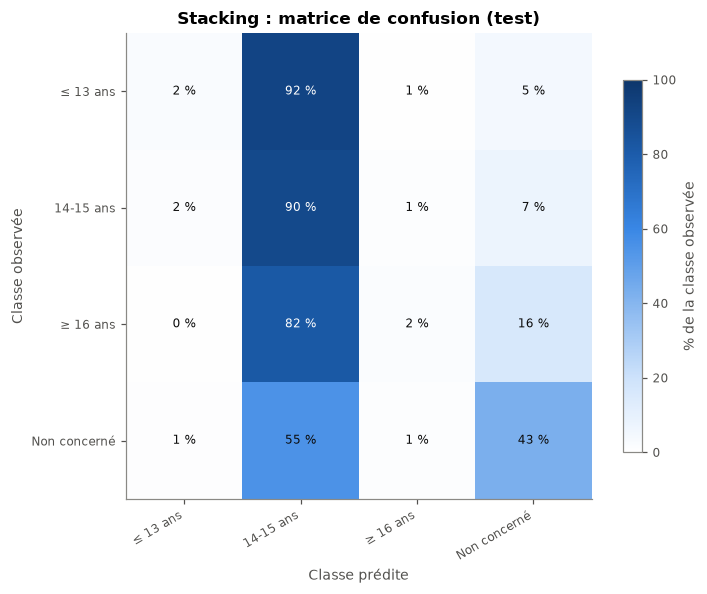

|  | % observé | % prédit | F1 |
| --- | --- | --- | --- |
| ≤ 13 ans | 18.957 | 1.436 | 0.045 |
| 14-15 ans | 40.720 | 81.893 | 0.596 |
| ≥ 16 ans | 21.816 | 1.349 | 0.038 |
| Non concerné | 18.507 | 15.322 | 0.466 |

```python
pred = FITTED[best_ensemble].predict(X_test)
cm = confusion_matrix(y_test, pred, labels=CLASSES, sample_weight=w_test)
cm_pct = cm / cm.sum(1, keepdims=True) * 100

from matplotlib.colors import LinearSegmentedColormap  # noqa: E402

fig, ax = plt.subplots(figsize=(7, 5.5))
im = ax.imshow(cm_pct, cmap=LinearSegmentedColormap.from_list("ramp", BLUE_RAMP), vmin=0,
               vmax=100)
for i in range(len(CLASSES)):
    for j in range(len(CLASSES)):
        ax.text(j, i, f"{cm_pct[i, j]:.0f} %", ha="center", va="center", fontsize=8,
                color="white" if cm_pct[i, j] > 55 else "#0b0b0b")
ax.set_xticks(range(len(CLASSES)), CLASSES, rotation=30, ha="right")
ax.set_yticks(range(len(CLASSES)), CLASSES)
ax.set_xlabel("Classe prédite")
ax.set_ylabel("Classe observée")
ax.set_title(f"{best_ensemble} : matrice de confusion (test)")
ax.grid(False)
fig.colorbar(im, ax=ax, label="% de la classe observée", shrink=0.8)
plt.tight_layout()
plt.show()

pred_share = w_test.groupby(pd.Series(pred, index=y_test.index)).sum() / w_test.sum() * 100
pd.DataFrame(
    {
        "% observé": (w_test.groupby(y_test).sum() / w_test.sum() * 100),
        "% prédit": pred_share,
        "F1": pd.Series(
            f1_score(y_test, pred, labels=CLASSES, average=None, sample_weight=w_test),
            index=CLASSES,
        ),
    }
).reindex(CLASSES).fillna(0).round(3)
```

### Probabilités prédites selon la classe observée

Probabilité moyenne attribuée à chaque classe : un modèle utile donne plus de probabilité à la bonne classe (diagonale) que la fréquence de base.

```python
proba = pd.DataFrame(FITTED[best_ensemble].predict_proba(X_test),
                     columns=FITTED[best_ensemble].classes_, index=y_test.index)[CLASSES]
mean_proba = proba.mul(w_test, axis=0).groupby(y_test).sum().div(
    w_test.groupby(y_test).sum(), axis=0
).reindex(CLASSES) * 100
base_rate = w_train.groupby(y_train).sum().reindex(CLASSES) / w_train.sum() * 100
mean_proba.loc["Fréquence de base"] = base_rate
mean_proba.round(1)
```

| Q19A_CLASSE | ≤ 13 ans | 14-15 ans | ≥ 16 ans | Non concerné |
| --- | --- | --- | --- | --- |
| ≤ 13 ans | 23.5 | 43.5 | 20.3 | 12.6 |
| 14-15 ans | 20.5 | 42.9 | 22.2 | 14.4 |
| ≥ 16 ans | 18.0 | 40.0 | 23.4 | 18.7 |
| Non concerné | 14.6 | 33.1 | 21.8 | 30.6 |
| Fréquence de base | 19.2 | 40.5 | 22.1 | 18.2 |

### AUC par classe (One-vs-Rest)

Pour chaque classe, probabilité qu'un jeune de cette classe reçoive une probabilité prédite plus élevée pour elle qu'un jeune d'une autre classe (0,5 = hasard). Contrairement au F1, elle ne dépend pas de la classe prédite : elle mesure le signal même pour les classes jamais prédites.

```python
auc_class = pd.DataFrame(
    {
        name: [
            roc_auc_score(y_test == c, FITTED[name].predict_proba(X_test)[:, i],
                          sample_weight=w_test)
            for i, c in enumerate(FITTED[name].classes_)
        ]
        for name in ("Logistique ridge", "XGBoost", best_ensemble)
    },
    index=FITTED[best_ensemble].classes_,
).reindex(CLASSES)
auc_class.loc["Macro"] = auc_class.mean()
auc_class.round(3)
```

|  | Logistique ridge | XGBoost | Stacking |
| --- | --- | --- | --- |
| ≤ 13 ans | 0.667 | 0.664 | 0.670 |
| 14-15 ans | 0.603 | 0.605 | 0.610 |
| ≥ 16 ans | 0.583 | 0.587 | 0.589 |
| Non concerné | 0.728 | 0.738 | 0.738 |
| Macro | 0.645 | 0.648 | 0.652 |